NetDisFit by NetSimR

# Distribution Fitting Report

Generated 20 November 2026, 13:55

## Key results

Data

2,500 rows

Liability claims: amounts and policy limits

Closest severity

Burr

Smallest K-S distance

## Data and settings

Data

**Source**

Liability claims: amounts and policy limits

**Rows**

2,500

**Columns**

4

Severity

**Claim sizes**

amount

**Reporting threshold**

None

**Policy limits**

The column policy_limit

**Claims at their limits**

204

## Severity

The distributions fitted to the claim sizes by maximum likelihood.

Claims

2,500

Mean

54,410

Median

25,560

Coefficient of variation

1.58

Largest claim

1,000,000

### Fitted distributions

| Distribution | Parameter 1 | Parameter 2 | Parameter 3 | Mean | K-S distance | A-D statistic | AIC |
| --- | --- | --- | --- | --- | --- | --- | --- |
| Normal | Mean 58,520 | Std. dev. 91,940 | — | 58,520 | 0.262 | — | 59,457.6 |
| LogNormal | mu 10.13 | sigma 1.478 | — | 75,070 | 0.0142 | — | 54,301.9 |
| Exponential | Mean 59,240 | — | — | 59,240 | 0.154 | — | 55,057.3 |
| Gamma | Scale 91,640 | Shape 0.667 | — | 61,120 | 0.0917 | — | 54,762 |
| Pareto | xm 45.5 | alpha 0.1468 | — | Infinite | 0.386 | — | 58,931 |
| Weibull | Scale 50,110 | Shape 0.7346 | — | 60,720 | 0.0594 | — | 54,600.4 |
| Burr | Scale 23,090 | alpha 0.9314 | gamma 1.204 | 196,400 | 0.0132 | — | 54,316.8 |
| Generalised Pareto | Location 0 | Scale 29,460 | Shape 0.6745 | 90,520 | 0.0218 | — | 54,344.8 |

Closest: Burr. 204 claims are at or above the policy limit, so the loss was at least the claim: each counts as the probability of exceeding it (censored), not as a claim of that size. The parameters are of all claims, before the limits. The K-S distance is to the Kaplan-Meier estimate of the claim sizes, which allows for the limits; the A-D statistic needs every claim's size, so it is not given. The Pareto starts at the smallest claim, the generalised Pareto at zero.

### Cumulative distribution

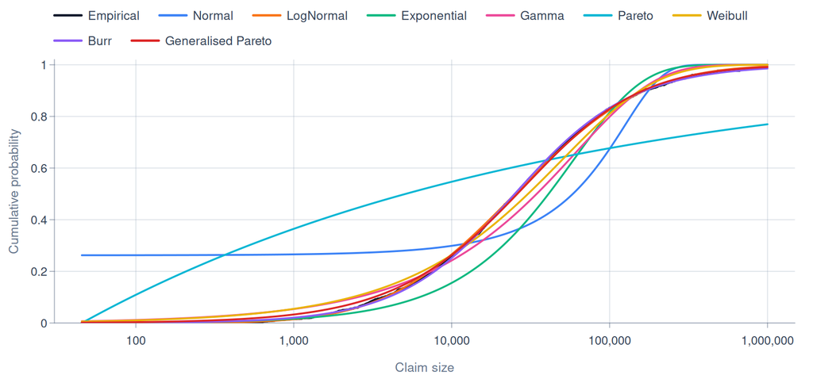

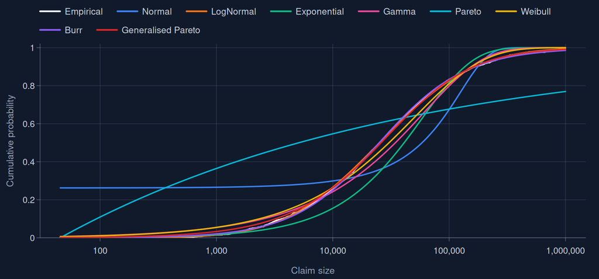

### Histogram of the claim sizes

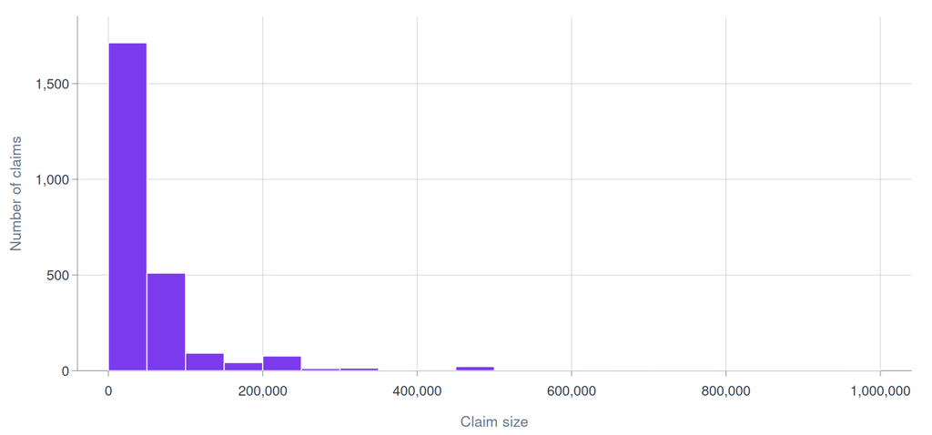

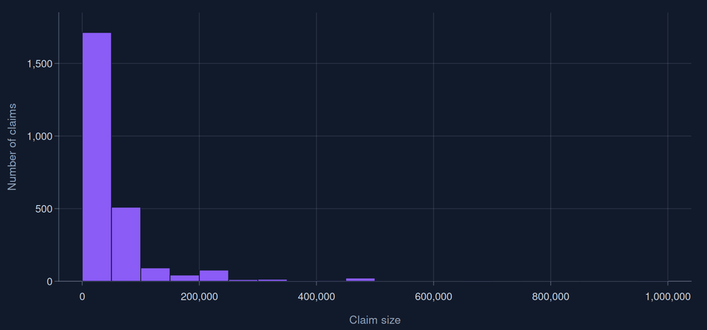

### Q-Q plot

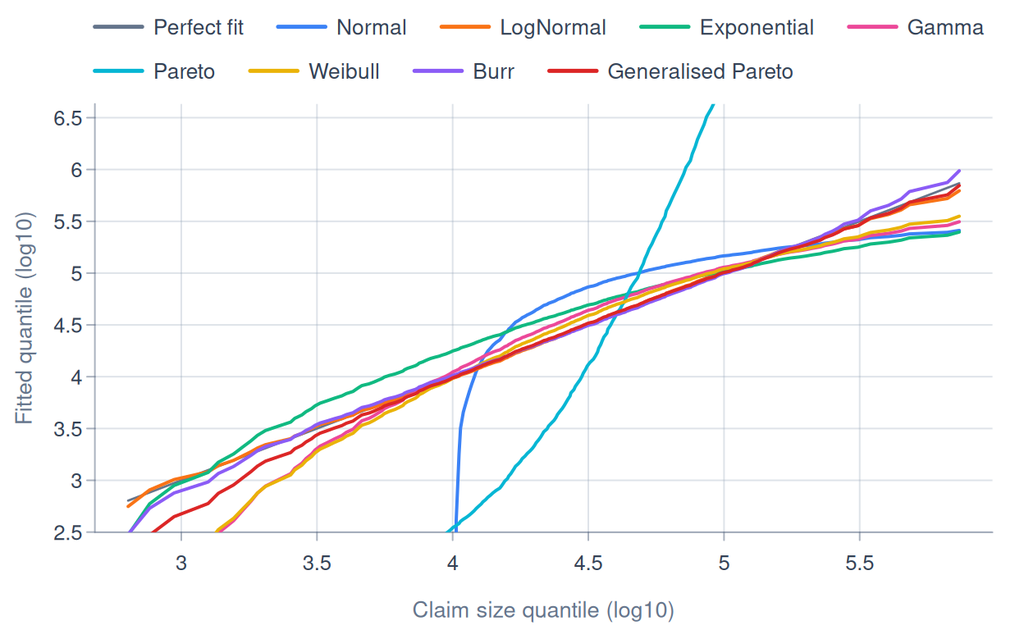

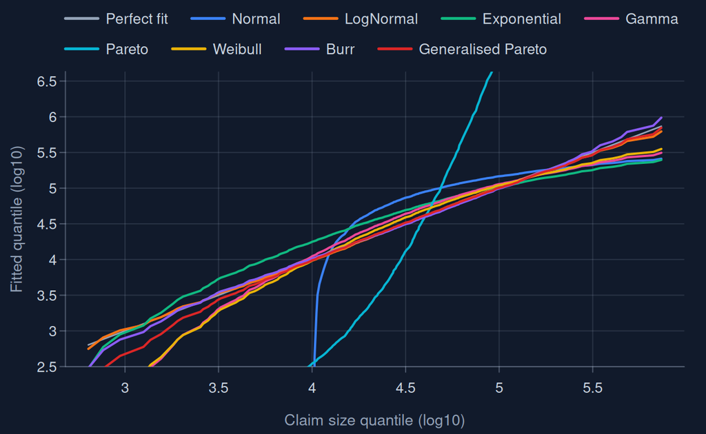

### P-P plot

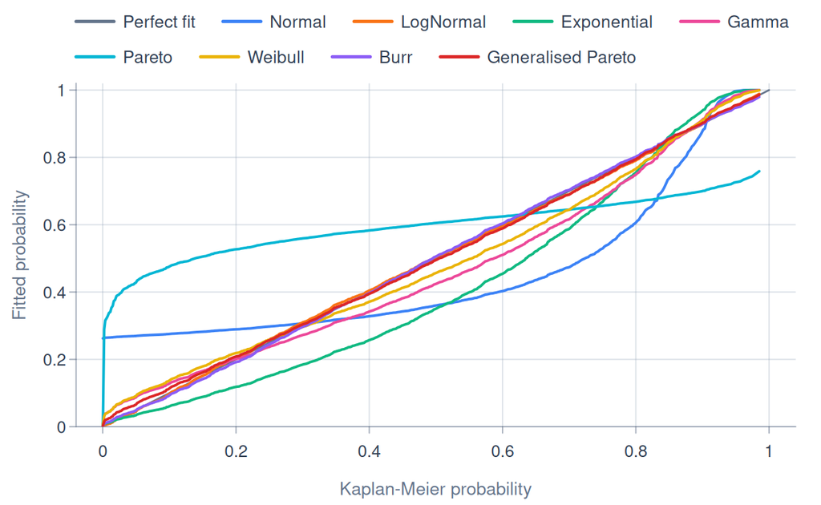

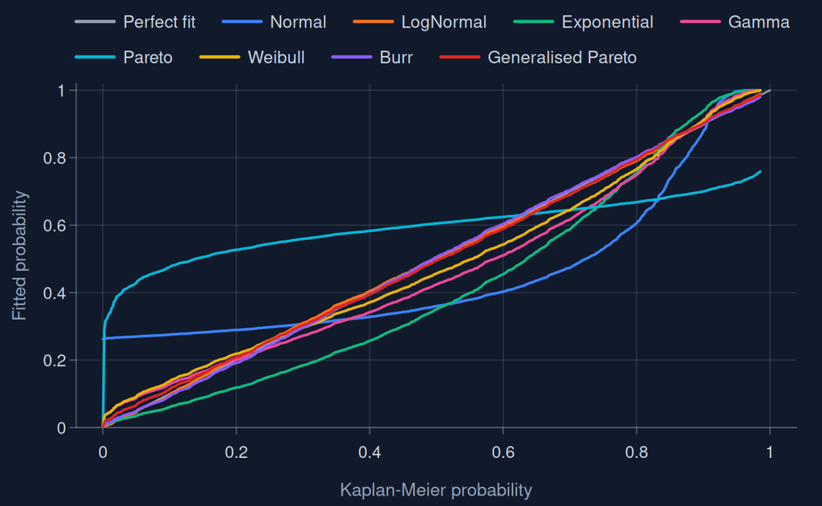

### Conditional tail expectations

| Distribution | CTE 90% | CTE 95% | CTE 99% | CTE 99.5% |
| --- | --- | --- | --- | --- |
| Claims | — | — | — | — |
| Normal | 219,900 | 248,200 | 303,600 | 324,400 |
| LogNormal | 433,800 | 651,200 | 1,487,000 | 2,044,000 |
| Exponential | 195,700 | 236,700 | 332,100 | 373,100 |
| Gamma | 238,100 | 296,000 | 433,600 | 493,600 |
| Pareto | Infinite | Infinite | Infinite | Infinite |
| Weibull | 260,100 | 335,000 | 527,500 | 617,300 |
| Burr | 1,656,000 | 3,084,000 | 12,990,000 | 24,120,000 |
| Generalised Pareto | 590,500 | 968,600 | 2,954,000 | 4,740,000 |

The conditional tail expectation (CTE, also TVaR or expected shortfall) at a level is the mean claim above that percentile. The claims at their policy limits hide the sizes of the largest losses, so the claims give no CTE: the fits estimate it, from the limits as well as the claims.

## How to read this report

- Each analysis is the one last run on its tab of the tool, with the columns and options under Data and settings.
- Frequency: the AIC weighs the fit against the number of parameters, and the lowest is the best. A zero-inflated model adds periods without a claim to a Poisson or a Negative Binomial.
- Severity: the K-S distance is the largest gap between a fitted and the empirical cumulative distribution; the Anderson-Darling statistic weighs the tails more. For both, lower is closer. The Q-Q plot shows how the tail fits, the P-P plot the body.
- The conditional tail expectation at a level is the mean claim above that percentile; a Hill plot that is level shows a Pareto tail, with the alpha it reads.
- The sliced and piecewise models fit Pareto tails above the points chosen in the tool: move them there and save the report again to compare.
- The tool's Export tab sends a fitted frequency and severity to NetSimulator, the claims simulator.